# Statistical Learning Final Exam 2020

20538061-1

`Due to: 10/08/20`

```r
rm(list = ls())
knitr::opts_chunk$set(echo = TRUE, warning = FALSE, error = FALSE)
set.seed(123)

setwd("C:/Users/matan/Dropbox/bachelor's/Statistics/Statistical learning and its applications/exam")
```

```r
library(dplyr)
```

```r
library(ggplot2)
library(ggExtra)
# install.packages("ggExtra")
```

```r
pisa = read.csv("pisa_israel_2018_fortargil.csv")
```

### In this home exam I will analyze and create prediction models for the PISA exams results in Israel 2018 using various statistical learning models.

The dependent variable will be PVREAD which is the score of the reading test of PISA, The other vaiables will be the independent variables.

Note that some of the variables are WLE (weighted likelihood estimates) and not regular scores.

Before I will began to answer the questions, I will perform a short exploratory data analysis, to see the behavour of the variables I have, add the language of each language code and see some connections between variables.

Using the [OECD library](https://www.oecd-ilibrary.org/docserver/9789264056275-en.pdf?expires=1595879160&id=id&accname=guest&checksum=4DB2E1FAF51C73BE9ADF8DAF1584B882), I found the meaning of the language-codes

```r
lng = pisa %>% select(LANGN)
lng = unique(lng)
# lng$LANGN
rm(lng)

pisa = pisa %>% mutate(language = "")
pisa$language = ifelse(pisa$LANGN == 500, "Arabic", pisa$language)
pisa$language = ifelse(pisa$LANGN == 313, "English", pisa$language)
pisa$language = ifelse(pisa$LANGN == 422, "Hebrew", pisa$language)
pisa$language = ifelse(pisa$LANGN == 825, "Other languages (ISR)", pisa$language)
pisa$language = ifelse(pisa$LANGN == 999, NA, pisa$language)
pisa$language = ifelse(pisa$LANGN == 614, "Russian etc", pisa$language)
pisa$language = ifelse(pisa$LANGN == 493, "French", pisa$language)
pisa$language = ifelse(pisa$LANGN == 171, "Ethopian", pisa$language)
pisa$language = ifelse(pisa$LANGN == 156, "Spanish", pisa$language)

#The values of 100 are just missing, same as 0s
pisa$STRATIO = ifelse(pisa$STRATIO == 100, NA, pisa$STRATIO)
pisa$STRATIO = ifelse(pisa$STRATIO == 0, NA, pisa$STRATIO)
```

Now let's look at a table of the languages and think if it seems OK:

```r
sort(table(pisa$language), decreasing = TRUE)
```

```
##
##                Hebrew                Arabic           Russian etc
##                  3608                  1169                   253
##               English Other languages (ISR)                French
##                   154                    86                    39
##               Spanish              Ethopian
##                    35                    33
```

It looks logical, the main languages are hebrew and arabic, some russian, then english, french and spanish as I could guess as a person who has some idea about the population in Israel.

In order to find any conclusion I examined each of the variables seperatly and then the connection between PVREAD and each of the variables.

I found some interesting connections that I am going to show:

First, I will show a boxplot of the reading scores with a seperation by the language spoken at home:

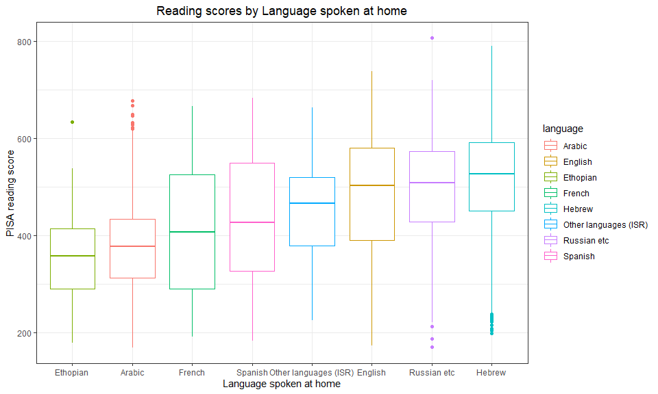

```r
# barplot(sort(table(pisa$language), decreasing = TRUE))

pisa %>% filter(!is.na(language)) %>%
  ggplot(aes(x = reorder(language, PVREAD, FUN = median), y = PVREAD, color = language))+
  geom_boxplot()+
  xlab("Language spoken at home")+
  ylab("PISA reading score")+
  ggtitle("Reading scores by Language spoken at home")+
  theme_bw()+
  theme(plot.title = element_text(hjust = 0.5))
```

```r
## A graph that shows what I will say about the efforts, You asked for just 2 graphs so I didn't show this one but used its conclusions.
# pisa %>% filter(!is.na(language) & language != "Not in list") %>%
#   ggplot(aes(x = reorder(language, EFFORT1, FUN = median), y = EFFORT1, color = language))+
#   geom_boxplot()+
#   xlab("Language spoken at home")+
#   ylab("Effort score")+
#   ggtitle("Effort scores by Language spoken at home")+
#   theme_bw()+
#   theme(plot.title = element_text(hjust = 0.5))
```

We can see that most of the students speak hebrew at home and students who speak languages other than hebrew have lower scores at reading, we can see it clearly when looking at students who speak Arabic at home. As recommended in the comments of the exam file, I will not use the fact of speaking Arabic or Ethiopian at home as a "pubishment" for those students. But I will use a binary variable of "Hebrew" at home" to examine the effect of speaking hebrew at home verses speaking other languages at home.

By looking at the efforts variable I saw that the effort of the students in the test is mostly 8 or above which means the students actually tried to succeed in the test and we may use the results to conclude, but we should keep in mind that there are 599 observations with no data about the effort. Also, the students who's effort were higher- got a better score, although the scores of effort of 10 seems lower somewhat. The efforts variable also showed that the students who speak Arabic at home tend to effort more than other students (although their scores were almost the lowest, maybe that is the thing which influences the effort of 10 PVREAD).

I tries to see if there is a difference between the joy from reading between students who speak different languages at home but I didn't see any. so I tried to see if speaking Hebrew at home changes the PISA reading results and if there is a change between those 2 groups of the way the reading results change when the joy from reading changes: I decided to plot it in a way where the x axis is the joy from reading (normalized between -1 and 1- by dividing by the maximum value), the y axis is the PISA reading score and the color differs between students who speak Hebrew at home and those who don't.

Added to that, I noticed that there are many more students who speak Hebrew at home so the graph might look biased due to many points of Hebrew speakers, to avoid that- I used only 1000 random observations from each of the 2 categories (Hebrew speakers at home and other languages), That is a total of 2000 observations which makes the plot clearer than using all the observations.

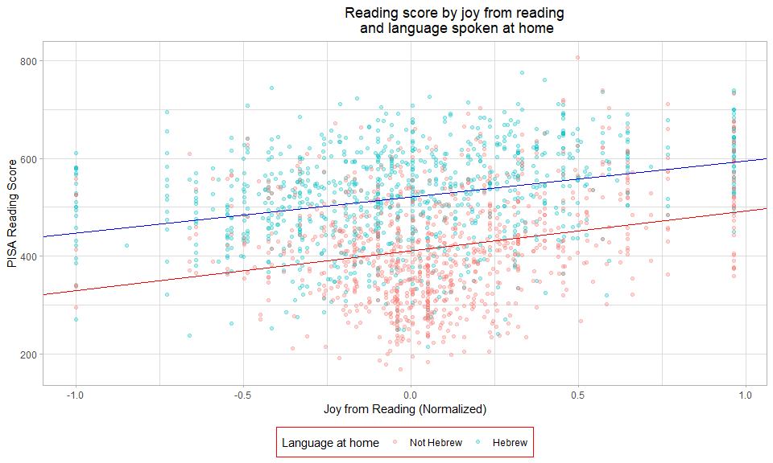

```r
set.seed(123)
pisa$joy_norm = pisa$JOYREAD/(max(abs(pisa$JOYREAD), na.rm = TRUE))
ind_heb = sample(which(pisa$language == "Hebrew"), 1000)
ind_non_heb = sample(which(pisa$language != "Hebrew"), 1000)
pisa_smpld = pisa[c(ind_heb, ind_non_heb),]
pisa_gg2 = pisa_smpld %>% filter(!is.na(joy_norm) & !is.na(language))

mod_hebrew = lm(PVREAD~joy_norm, data = pisa_gg2 %>% filter(language == "Hebrew"))
mod_non_hebrew = lm(PVREAD~joy_norm, data = pisa_gg2 %>% filter(language != "Hebrew"))


pisa_gg2 %>%
  ggplot(aes(x = joy_norm, y = PVREAD, color = language=="Hebrew"))+
  geom_point(alpha = 0.3)+
  xlab("Joy from Reading (Normalized)")+
  ylab("PISA Reading Score")+
  ggtitle("Reading score by joy from reading\nand language spoken at home")+
  scale_color_discrete(name = "Language at home", labels = c("Not Hebrew", "Hebrew"))+
  theme_light()+
  theme(plot.title = element_text(hjust = 0.6))+
  theme(legend.box.background = element_rect(fill = "black"), legend.background = element_rect(color = "red"), legend.position = "bottom")+
  geom_abline(slope = mod_hebrew$coeff[2], intercept = mod_hebrew$coeff[1], color = "blue")+
  geom_abline(slope = mod_non_hebrew$coeff[2], intercept = mod_non_hebrew$coeff[1], color = "red")
```

It seems that overall, the hebrew speakers have higher scores in the reading PISA test than those who don't (speak Hebrew at home) and there is a positive connection between the joy from reading to the PISA reading score no matter the language spoken at home, And I can even say that the effect of joy from reading for students who speak another language at home is larger than the students who speak hebrew at home (Maybe because of the multilingualism?)

**The regression formulas are:**

Students who speak Hebrew at home:

$\hat{PVREAD} = 523.66 + 66.71*JoyReading_Normalized$

All the coeeficients are significant.

### Question 2

I am going to create a KNN function for students so we will be able to use it between students. In order to do so, I will create 2 distance functions between any two students- One based on the student-level variables and the other based on the class-level variables. The Word file you gave us says we should assume that we use just one class at each school (so no need of distance function based on school-level). Then, I will create a KNN prediction (based on a weighted average between the two distance functions) and at the end I will validate and test the model.

Before heading towards the distance calculations, I will fill the missing values (The NA values), I will consider two main type of variables- categorical and numeric. For the categorical missing values I will use a random value from the empirical distribution of the variable. For the numerical missing values I will group the observations by the System and the language spoken at home, then I will use the average of the group the missing value is from (if the System is missing- use the distribution/average of all data, if language is missing- use the the distribution/average of the System).

```r
pisa_raw = pisa


replace_missing_values = function(pisa_fun){

  for(i in c(1:nrow(pisa_fun))){
    #if the System is NA
      if(is.na(pisa_fun[i,"System"])){
        #Numerical
        pisa_fun[i,"AGE"] = ifelse(is.na(pisa_fun[i,"AGE"]), mean(pisa_fun$AGE, na.rm = T), pisa_fun[i,"AGE"])
        pisa_fun[i,"PAREDINT"] = ifelse(is.na(pisa_fun[i,"PAREDINT"]), mean(pisa_fun$PAREDINT, na.rm = T), pisa_fun[i,"PAREDINT"])
        pisa_fun[i,"ESCS"] = ifelse(is.na(pisa_fun[i,"ESCS"]), mean(pisa_fun$ESCS, na.rm = T), pisa_fun[i,"ESCS"])
        pisa_fun[i,"JOYREAD"] = ifelse(is.na(pisa_fun[i,"JOYREAD"]), mean(pisa_fun$JOYREAD, na.rm = T), pisa_fun[i,"JOYREAD"])
        pisa_fun[i,"DISCLIMA"] = ifelse(is.na(pisa_fun[i,"DISCLIMA"]), mean(pisa_fun$DISCLIMA, na.rm = T), pisa_fun[i,"DISCLIMA"])
        pisa_fun[i,"TEACHSUP"] = ifelse(is.na(pisa_fun[i,"TEACHSUP"]), mean(pisa_fun$TEACHSUP, na.rm = T), pisa_fun[i,"TEACHSUP"])
        pisa_fun[i,"STAFFSHORT"] = ifelse(is.na(pisa_fun[i,"STAFFSHORT"]), mean(pisa_fun$STAFFSHORT, na.rm = T), pisa_fun[i,"STAFFSHORT"])
        pisa_fun[i,"EDUSHORT"] = ifelse(is.na(pisa_fun[i,"EDUSHORT"]), mean(pisa_fun$EDUSHORT, na.rm = T), pisa_fun[i,"EDUSHORT"])
        pisa_fun[i,"TOTAT"] = ifelse(is.na(pisa_fun[i,"TOTAT"]), mean(pisa_fun$TOTAT, na.rm = T), pisa_fun[i,"TOTAT"])
        pisa_fun[i,"STRATIO"] = ifelse(is.na(pisa_fun[i,"STRATIO"]), mean(pisa_fun$STRATIO, na.rm = T), pisa_fun[i,"STRATIO"])


        #Categorical
        pisa_fun[i,"EFFORT1"] = ifelse(is.na(pisa_fun[i,"EFFORT1"]),
                                   sample((pisa_fun %>% filter(!is.na(EFFORT1)))$EFFORT1, 1), pisa_fun[i,"EFFORT1"])
        pisa_fun[i,"DURECEC"] = ifelse(is.na(pisa_fun[i,"DURECEC"]),
                                   sample((pisa_fun %>% filter(!is.na(DURECEC)))$DURECEC, 1), pisa_fun[i,"DURECEC"])
        pisa_fun[i,"CLSIZE"] = ifelse(is.na(pisa_fun[i,"CLSIZE"]),
                                  sample((pisa_fun %>% filter(!is.na(CLSIZE)))$CLSIZE, 1), pisa_fun[i,"CLSIZE"])
        pisa_fun[i,"language"] = ifelse(is.na(pisa_fun[i,"language"]),
                                    sample((pisa_fun %>% filter(!is.na(language)))$language, 1), pisa_fun[i,"language"])
        #if language was missing than the LANGN was missing too- replace the NA with the relevant language
        pisa_fun[i,"LANGN"] = pisa_fun$LANGN[which((pisa_fun[i,"language"] == pisa_fun$language) &(!is.na(pisa_fun$LANGN)))][1]


        #If the System is available but no language/ has both System and language
      } else{
        if(is.na(pisa_fun[i,"language"])){ #language is NA
          tmp = pisa_fun %>% filter(System == pisa_fun[i,"System"])


           #Numerical
          pisa_fun[i,"AGE"] = ifelse(is.na(pisa_fun[i,"AGE"]), mean(tmp$AGE, na.rm = T), pisa_fun[i,"AGE"])
          pisa_fun[i,"PAREDINT"] = ifelse(is.na(pisa_fun[i,"PAREDINT"]), mean(tmp$PAREDINT, na.rm = T), pisa_fun[i,"PAREDINT"])
          pisa_fun[i,"ESCS"] = ifelse(is.na(pisa_fun[i,"ESCS"]), mean(tmp$ESCS, na.rm = T), pisa_fun[i,"ESCS"])
          pisa_fun[i,"JOYREAD"] = ifelse(is.na(pisa_fun[i,"JOYREAD"]), mean(tmp$JOYREAD, na.rm = T), pisa_fun[i,"JOYREAD"])
          pisa_fun[i,"DISCLIMA"] = ifelse(is.na(pisa_fun[i,"DISCLIMA"]), mean(tmp$DISCLIMA, na.rm = T), pisa_fun[i,"DISCLIMA"])
          pisa_fun[i,"TEACHSUP"] = ifelse(is.na(pisa_fun[i,"TEACHSUP"]), mean(tmp$TEACHSUP, na.rm = T), pisa_fun[i,"TEACHSUP"])
          pisa_fun[i,"STAFFSHORT"] = ifelse(is.na(pisa_fun[i,"STAFFSHORT"]), mean(tmp$STAFFSHORT, na.rm = T), pisa_fun[i,"STAFFSHORT"])
          pisa_fun[i,"EDUSHORT"] = ifelse(is.na(pisa_fun[i,"EDUSHORT"]), mean(tmp$EDUSHORT, na.rm = T), pisa_fun[i,"EDUSHORT"])
          pisa_fun[i,"TOTAT"] = ifelse(is.na(pisa_fun[i,"TOTAT"]), mean(tmp$TOTAT, na.rm = T), pisa_fun[i,"TOTAT"])
          pisa_fun[i,"STRATIO"] = ifelse(is.na(pisa_fun[i,"STRATIO"]), mean(tmp$STRATIO, na.rm = T), pisa_fun[i,"STRATIO"])



          #Categorical
          pisa_fun[i,"EFFORT1"] = ifelse(is.na(pisa_fun[i,"EFFORT1"]),
                                     sample((tmp %>% filter(!is.na(EFFORT1)))$EFFORT1, 1), pisa_fun[i,"EFFORT1"])
          pisa_fun[i,"DURECEC"] = ifelse(is.na(pisa_fun[i,"DURECEC"]),
                                     sample((tmp %>% filter(!is.na(DURECEC)))$DURECEC, 1), pisa_fun[i,"DURECEC"])
          pisa_fun[i,"CLSIZE"] = ifelse(is.na(pisa_fun[i,"CLSIZE"]),
                                    sample((tmp %>% filter(!is.na(CLSIZE)))$CLSIZE, 1), pisa_fun[i,"CLSIZE"])
          pisa_fun[i,"language"] = ifelse(is.na(pisa_fun[i,"language"]),
                                    sample((tmp %>% filter(!is.na(language)))$language, 1), pisa_fun[i,"language"])

        #if language was missing than the LANGN was missing too- replace the NA with the relevant language
        pisa_fun[i,"LANGN"] = pisa_fun$LANGN[which((pisa_fun[i,"language"] == pisa_fun$language) &(!is.na(pisa_fun$LANGN)))][1]



        }else{
          tmp = pisa_fun %>% filter(System == pisa_fun[i,"System"] & language == pisa_fun[i, "language"])


           #Numerical
          pisa_fun[i,"AGE"] = ifelse(is.na(pisa_fun[i,"AGE"]), mean(tmp$AGE, na.rm = T), pisa_fun[i,"AGE"])
          pisa_fun[i,"PAREDINT"] = ifelse(is.na(pisa_fun[i,"PAREDINT"]), mean(tmp$PAREDINT, na.rm = T), pisa_fun[i,"PAREDINT"])
          pisa_fun[i,"ESCS"] = ifelse(is.na(pisa_fun[i,"ESCS"]), mean(tmp$ESCS, na.rm = T), pisa_fun[i,"ESCS"])
          pisa_fun[i,"JOYREAD"] = ifelse(is.na(pisa_fun[i,"JOYREAD"]), mean(tmp$JOYREAD, na.rm = T), pisa_fun[i,"JOYREAD"])
          pisa_fun[i,"DISCLIMA"] = ifelse(is.na(pisa_fun[i,"DISCLIMA"]), mean(tmp$DISCLIMA, na.rm = T), pisa_fun[i,"DISCLIMA"])
          pisa_fun[i,"TEACHSUP"] = ifelse(is.na(pisa_fun[i,"TEACHSUP"]), mean(tmp$TEACHSUP, na.rm = T), pisa_fun[i,"TEACHSUP"])
          pisa_fun[i,"STAFFSHORT"] = ifelse(is.na(pisa_fun[i,"STAFFSHORT"]), mean(tmp$STAFFSHORT, na.rm = T), pisa_fun[i,"STAFFSHORT"])
          pisa_fun[i,"EDUSHORT"] = ifelse(is.na(pisa_fun[i,"EDUSHORT"]), mean(tmp$EDUSHORT, na.rm = T), pisa_fun[i,"EDUSHORT"])
          pisa_fun[i,"TOTAT"] = ifelse(is.na(pisa_fun[i,"TOTAT"]), mean(tmp$TOTAT, na.rm = T), pisa_fun[i,"TOTAT"])
          pisa_fun[i,"STRATIO"] = ifelse(is.na(pisa_fun[i,"STRATIO"]), mean(tmp$STRATIO, na.rm = T), pisa_fun[i,"STRATIO"])



          #Categorical
          pisa_fun[i,"EFFORT1"] = ifelse(is.na(pisa_fun[i,"EFFORT1"]),
                                     sample((tmp %>% filter(!is.na(EFFORT1)))$EFFORT1, 1), pisa_fun[i,"EFFORT1"])
          pisa_fun[i,"DURECEC"] = ifelse(is.na(pisa_fun[i,"DURECEC"]),
                                     sample((tmp %>% filter(!is.na(DURECEC)))$DURECEC, 1), pisa_fun[i,"DURECEC"])
          pisa_fun[i,"CLSIZE"] = ifelse(is.na(pisa_fun[i,"CLSIZE"]),
                                    sample((tmp %>% filter(!is.na(CLSIZE)))$CLSIZE, 1), pisa_fun[i,"CLSIZE"])


        }
      }


  }



  #replace Nan values for groups with NA for all data
  #Numerical
  pisa_fun$AGE = ifelse(is.na(pisa_fun$AGE), mean(pisa_fun$AGE, na.rm = T), pisa_fun$AGE)
  pisa_fun$PAREDINT = ifelse(is.na(pisa_fun$PAREDINT), mean(pisa_fun$PAREDINT, na.rm = T), pisa_fun$PAREDINT)
  pisa_fun$ESCS = ifelse(is.na(pisa_fun$ESCS), mean(pisa_fun$ESCS, na.rm = T), pisa_fun$ESCS)
  pisa_fun$JOYREAD = ifelse(is.na(pisa_fun$JOYREAD), mean(pisa_fun$JOYREAD, na.rm = T), pisa_fun$JOYREAD)
  pisa_fun$DISCLIMA = ifelse(is.na(pisa_fun$DISCLIMA), mean(pisa_fun$DISCLIMA, na.rm = T), pisa_fun$DISCLIMA)
  pisa_fun$TEACHSUP = ifelse(is.na(pisa_fun$TEACHSUP), mean(pisa_fun$TEACHSUP, na.rm = T), pisa_fun$TEACHSUP)
  pisa_fun$STAFFSHORT = ifelse(is.na(pisa_fun$STAFFSHORT), mean(pisa_fun$STAFFSHORT, na.rm = T), pisa_fun$STAFFSHORT)
  pisa_fun$EDUSHORT = ifelse(is.na(pisa_fun$EDUSHORT), mean(pisa_fun$EDUSHORT, na.rm = T), pisa_fun$EDUSHORT)
  pisa_fun$TOTAT = ifelse(is.na(pisa_fun$TOTAT), mean(pisa_fun$TOTAT, na.rm = T), pisa_fun$TOTAT)
  pisa_fun$STRATIO = ifelse(is.na(pisa_fun$STRATIO), mean(pisa_fun$STRATIO, na.rm = T), pisa_fun$STRATIO)


  #Categorical
  pisa_fun$EFFORT1 = ifelse(is.na(pisa_fun$EFFORT1), sample((pisa_fun %>% filter(!is.na(EFFORT1)))$EFFORT1, 1), pisa_fun$EFFORT1)

  pisa_fun$DURECEC = ifelse(is.na(pisa_fun$DURECEC), sample((pisa_fun %>% filter(!is.na(DURECEC)))$DURECEC, 1), pisa_fun$DURECEC)

  pisa_fun$CLSIZE = ifelse(is.na(pisa_fun$CLSIZE), sample((pisa_fun %>% filter(!is.na(CLSIZE)))$CLSIZE, 1), pisa_fun$CLSIZE)

  pisa_fun$language = ifelse(is.na(pisa_fun$language), sample((pisa_fun %>% filter(!is.na(language)))$language, 1), pisa_fun$language)




  #normalize JOYREAD
  pisa_fun$joy_norm = pisa_fun$JOYREAD/(max(abs(pisa_fun$JOYREAD), na.rm = TRUE))

  return(pisa_fun)

}

pisa = replace_missing_values(pisa_raw)
```

First, Let's create a distance function between two classes (class-level variables):: The class variables are: Categorical variable: System (distance Calculated as 0.25 for each step in the range [Israel Arabic- Israel Ultra Orthodox Girls]). Numeric variables: STRATIO, TOTAT, CLSIZE (Descrete), EDUSHORT and STAFFSHORT. I used L2 norm to calculate the difference between two observations for the numeric.

After filling in the missing values I divided each variable by it's standard deviation and calculated the L2 norm as the distance, As mentioned above.

```r
class_distance = function(ob_a, dta){
  dis = 0

  #distance between systems- same system = 0, I made a range of systems where orthodox is one edge and arabic is the other, the distance between systems is between 0 and 1
  sys_dist = c("Israel Ultra Orthodox Girls", "Israel Hebrew Religious", "Israel Hebrew Secular", "Israel Arabic")

  #Make the systems numeric (as ordinal)
  dta = dta %>% mutate(System_ord = ifelse(System == "Israel Ultra Orthodox Girls", 1,
                      ifelse(System == "Israel Hebrew Religious",2,
                      ifelse(System == "Israel Hebrew Secular", 3,
                      ifelse(System == "Israel Arabic", 4, NA)))))

  dis = dis + abs(which(ob_a$System == sys_dist) - dta$System_ord)/4

  #numeric variables:
  dis_class_vars = c("STRATIO", "TOTAT", "CLSIZE", "EDUSHORT", "STAFFSHORT")
  #The sd of each column
  sd_class_vars = c(sd(pisa$STRATIO), sd(pisa$TOTAT), sd(pisa$CLSIZE), sd(pisa$EDUSHORT), sd(pisa$STAFFSHORT))

  #   #The mean of each column, not needed because it falls in the distance function when using oba-obb
  # mean_class_vars = c(mean(pisa$DISCLIMA, na.rm = T), mean(pisa$TEACHSUP, na.rm = T), mean(pisa$STRATIO, na.rm = T), mean(pisa$TOTAT, na.rm = T), mean(pisa$CLSIZE, na.rm = T), mean(pisa$EDUSHORT, na.rm = T), mean(pisa$STAFFSHORT, na.rm = T))
  #


  #take the relevant variables and replace NAs with the mean of the variable- if both obs have the same missing value- than the distance of this variable is 0
  ob_a = ob_a[,dis_class_vars]
  dta = dta[,dis_class_vars]




  #The distance function is thesqrt of the sum of the distances while I chose to impute the NA values by averages by group
  dis = dis +  sqrt(apply((((t(ob_a)-dta)/sd_class_vars)^2), 1, sum))

  return(dis)
}
```

Now, Let's create a distance function between a student and a dataframe of students (student-level variables): The student variables are: Categorical variable: language (the distance is 1 if not the same language spoken at home) Ordinal variables: EFFORT1 and DURECEC (the distance is the L1 norm). Numeric variables: AGE, PAREDINT, ESCS, JOYREAD, DISCLIMA AND TEACHSUP. I used diveded by the standard deviation and used square root of the L2 norm to calculate the difference between two observations for the numeric variables.

```r
student_distance = function(ob_a, dta){

  #just to make sure these are dataframes just like pisa (with names)

  ob_a = as.data.frame(ob_a)
  if(length(ob_a) != 18){
    ob_a$PVREAD = NA
  }


  dta = as.data.frame(dta)
  if(length(dta) != 18){
    dta$PVREAD = NA
  }

  names(ob_a) = names(pisa)
  names(dta) = names(pisa)

  #start the distance variable
  dis = 0

  #numeric variables:
  dis_student_vars_numeric = c("AGE", "PAREDINT", "ESCS", "JOYREAD", "DISCLIMA", "TEACHSUP")

  ## dis_student_categ = c("EFFORT1", "DURECEC", "language")
  #Add 1 if not same language
  dis = dis + as.numeric(ob_a$language!=dta$language)

  #Make the ordinal variables numeric

  #Add L1 norm of ordinal variables (diveded by the standard deviation of the variable)
  dis = dis + abs(ob_a$EFFORT1- dta$EFFORT1)/sd(pisa$EFFORT1) + abs(ob_a$DURECEC- dta$DURECEC)/sd(pisa$DURECEC)

  #The sd of each numeric column
  sd_student_vars = c(sd(pisa$AGE), sd(pisa$PAREDINT), sd(pisa$ESCS), sd(pisa$JOYREAD), sd(pisa$DISCLIMA), sd(pisa$TEACHSUP))

  #take the relevant variables and replace NAs with the mean of the variable- if both obs have the same missing value- than the distance of this variable is 0
  ob_a = ob_a[,dis_student_vars_numeric]
  dta = dta[,dis_student_vars_numeric]


  #use sqrt of the L2 norm for the numeric variables, use the log of the distance for PAREDINT
  dd = (ob_a$PAREDINT-dta$PAREDINT)/sd(pisa$PAREDINT)

  dis = dis +  as.vector(sqrt(apply((((t(ob_a)-dta)/sd_student_vars)^2), 1, sum))) +
    abs(dd)

  return(dis)
}
```

Now I will create a function that calculated the distance between an observation and a dataframe with alpha as the weight of the student-level distance

```r
calculate_distance = function(dta, ob_a, alph, student_distance, class_distance){
  return(alph*student_distance(ob_a, dta) + (1-alph)*class_distance(ob_a, dta))
}
```

Here I will create a function that for a given observation, K and alpha- will return the prediction using my KNN function.

```r
predict_KNN = function(ob, dta, K, alph, student_distance, class_distance){


  if(nrow(dta) < K){
    return(mean(dta$PVREAD))
  }


  distances = calculate_distance(dta = dta, ob_a = ob, alph = alph, student_distance = student_distance, class_distance = class_distance)

  min_vals = sort(distances)[1:K]
  min_ind = which(distances %in% min_vals)

  prediction_KNN = mean(dta$PVREAD[min_ind])
  return(prediction_KNN)
}



predict_multi_KNN = function(test, train, K, alph, student_distance, class_distance){

  predictions = c()
  for(i in c(1:nrow(test))){
    predictions = append(predictions, predict_KNN(test[i,], train, alph = alph, K = K, student_distance = student_distance, class_distance = class_distance))
  }

  return(predictions)
}
```

In order to check the fir of the model and which arguments give us the best results I will need to compare between them, we were asked to use RMSE for this, here is a function that calculates the RMSE:

```r
RMSE = function(res_guess, test_pv){
  return(sqrt(mean((res_guess-test_pv)^2)))
}
```

### Cross-Validation

In order to choose the best $\alpha$ and K, I will use P-Fold-Cross-Validation (K fold but I already have variable K) with various Ks and $\alpha$s. for each, I will calculate the RMSE and visualize it with a plot to decide which combination is the best.

```r
#P is the number of folds in the P-fold Cross Validation
uniform_CV = function(dta, P){

  errs = c()
  a_cv = c()
  k_cv = c()


  Ks = c(10:60)
  alphs = c(0.15, 0.3, 0.7, 0.9)
  P = 10 #10 Fold Cross Validation  (P = 10)
  for(a in alphs){
    for(k in Ks){

      ers = c()
      resample = dta[sample(c(1:nrow(dta)), size = nrow(dta)),]

      for(i in c(1:P)){
        rng = c(as.integer(floor(nrow(resample)/P)*(i-1)+1) : as.integer(floor(nrow(resample)/P*i)))
        # rng = floor(nrow(resample)*0.9) #If I want to use train/test with 1foldCV
        train = resample[-rng,]
        test = resample[rng,]
        res = predict_multi_KNN(test %>% select(-PVREAD), train = train, K = k, alph = a, student_distance= student_distance, class_distance = class_distance)
        ers = append(ers, RMSE(res, test$PVREAD))
      }
      errs = append(errs, mean(ers))
      #just to make it easier to make the plot later
      a_cv = append(a_cv, a)
      k_cv = append(k_cv, k)
    }

  }


  # res = predict_multi_KNN(test %>% select(-PVREAD), pisa[-sam,], K = K, alph = alph, student_distance= student_distance, class_distance = class_distance)
  r = as.data.frame(cbind(errs, a_cv, k_cv))
  names(r) = c("errs", "alphas", "Ks")
  return(r)

}

# dfs = uniform_CV(pisa, P = nrow(dta))

#To use the data I already got from the running of the cross validations with various alphas and Ks
dfs = read.csv('uniform CV3.csv')
```

```r
# dta = pisa
#Leave one class out
class_CV = function(dta){
  #Create variable of class number

  dta = dta %>% group_by(System, STRATIO, TOTAT, CLSIZE, EDUSHORT, STAFFSHORT) %>%
    mutate(class_num = group_indices()) %>% ungroup

  errs = c()
  a_cv = c()
  k_cv = c()

  Ks = c(10:60)
  alphs = c(0.15, 0.3, 0.7, 0.9)
  # P = 5

  for(a in alphs){
    for(k in Ks){

      ers = c()
      #Leave One out classes
      for(i in c(1:max(dta$class_num))){
        train = dta %>% filter(class_num != i)
        test = dta %>% filter(class_num == i)
        res = predict_multi_KNN(test %>% select(-PVREAD), train = train, K = k, alph = a, student_distance= student_distance, class_distance = class_distance)
        ers = append(ers, RMSE(res, test$PVREAD))
      }
      errs_class = append(errs_class, mean(ers))
      #just to make it easier to make the plot later
      a_cv_class = append(a_cv_class, a)
      k_cv_class = append(k_cv_class, k)
    }

  }


  # res = predict_multi_KNN(test %>% select(-PVREAD), pisa[-sam,], K = K, alph = alph, student_distance= student_distance, class_distance = class_distance)
  r = as.data.frame(cbind(errs_class, a_cv_class, k_cv_class))
  names(r) = c("errs", "alphas", "Ks")
  return(r)

}

##Instead of using the CV all over again each time I Knit the RMD file- I saved the data as csv
# classes_r = class_CV(dta = pisa)
classes_r = read.csv('classes CV3.csv')
```

Figures of the RMSE v.s. the Ks and coloured by the $\alpha$s

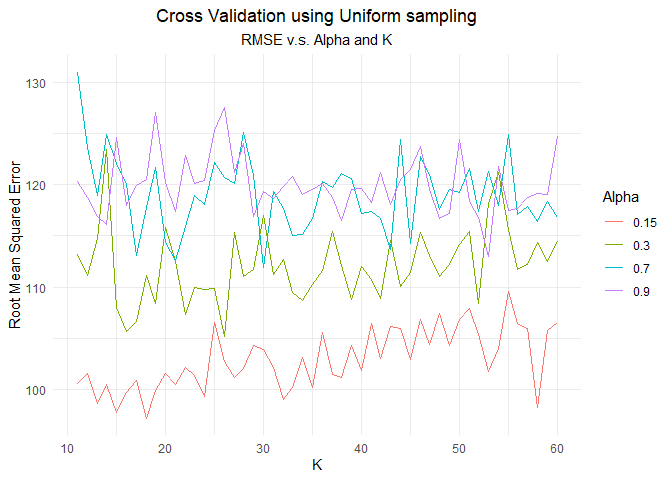

```r
library(ggplot2)
ggplot(dfs, aes(x = Ks, y = errs)) +
  geom_line(aes(col = as.factor(alphas))) +
  xlab("K")+
  ylab("Root Mean Squared Error")+
  theme_minimal()+
  ggtitle("Cross Validation using Uniform sampling", subtitle = "RMSE v.s. Alpha and K") +
  theme(plot.title = element_text(hjust = 0.5), plot.subtitle = element_text(hjust = 0.5))+
  labs(col = "Alpha")
```

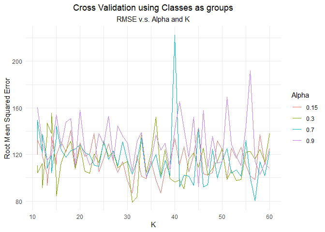

```r
ggplot(classes_r, aes(x = Ks, y = errs)) +
  geom_line(aes(col = as.factor(alphas))) +
  xlab("K")+
  ylab("Root Mean Squared Error")+
  theme_minimal()+
  ggtitle("Cross Validation using Classes as groups", subtitle = "RMSE v.s. Alpha and K") +
  theme(plot.title = element_text(hjust = 0.5), plot.subtitle = element_text(hjust = 0.5))+
  labs(col = "Alpha")
```

```r
errs = c()
dta = pisa

k = c(13)
a = c(0.15)

ers = c()
resample_ind = sample(c(1:nrow(dta)), size = nrow(dta))[c(1:floor(0.7*nrow(dta)))]
test = (pisa[-resample_ind,]) %>% select(-PVREAD)
train = dta[resample_ind,]
res = predict_multi_KNN(test = test, train = train, K = k, alph = a, student_distance= student_distance, class_distance = class_distance)

ers = append(ers, (test$PVREAD - res))


best_uniform = as.data.frame(ers)
names(best_uniform) = c("residuals")
# hist(best_uniform$residuals)
# qqnorm(best_uniform$residuals)
# summary(best_uniform$residuals)
```

### Question 3- Create my own model for predicting PVREAD (out of sample)

Between all the models I know, I needed to choose one that uses some ordinal values, some numerical values and some categorical. And predicts a numerical value with the lowest RMSE. Therefore, I chose to use Linear Regression but I wanted to make sure the model is the best I can produce so I used interactions and dummy variables when needed and also monotonically increasing functions on variables. After checking the residuals I saw that I have a problem of Heteroscedasticity which made me think and decide to use WLS (Weighted Least Squares) with the weights of 1/sd^2 (as we learnt in Regression and Statistical models course).

First, I filled the missing values of the test data by combining it to the train data, using my function and then deleting it from the training data. Then, I added new variables (The ones that I added to the training data for the WLS model in order to predict using that model.

The model I created is using WLS with binary variables (boolean) such as "finished_HS" which gives 1 to any student that at least one of his parents graduated high-school. I also added interaction variables such as class-size * Teacher's support and (Student/Teach ratio * Total amount of teachers in the school / Class size. I added the interaction AGE*JOYREAD which uses the combined effect of the age and the joy from reading. In addition to that, I used numerical variables and factor (categorical) variables from the original data.

After completing this model, I tried using RandomForest and watched the results but I decided to stay with my WLS model and not the RandomForest.

When checking new variables to add I tried to think what could explain the results of the reading test from the variables I have and watched the histogram of the variable (original or the one I create) and it's qqnorm plot. After doing so, if it doesn't seem like a linear connection between the PVREAD and the variable- I tried to change it so it will have this kind of connection and if it worked and it's logical- I added it to the model. For each variable I added to the model- I checked in-sample and out-of-sample RMSE and decided if the variable manages to make the model better or not. If yes- I let it stay. (Forward Selection using RMSE).

```r
my_prediction_model = function(test){
  library(dplyr)
  test = test %>% mutate(PVREAD = ifelse(is.na(PVREAD), NA, PVREAD))
  test$joy_norm = NA

  setwd("C:/Users/matan/Dropbox/bachelor's/Statistics/Statistical learning and its applications/exam")
  pisa = read.csv("pisa_israel_2018_fortargil.csv")



  test_save = test

  train = pisa %>% mutate(language = "")
  train$language = ifelse(train$LANGN == 500, "Arabic", train$language)
  train$language = ifelse(train$LANGN == 313, "English", train$language)
  train$language = ifelse(train$LANGN == 422, "Hebrew", train$language)
  train$language = ifelse(train$LANGN == 825, "Other languages (ISR)", train$language)
  train$language = ifelse(train$LANGN == 999, NA, train$language)
  train$language = ifelse(train$LANGN == 614, "Russian etc", train$language)
  train$language = ifelse(train$LANGN == 493, "French", train$language)
  train$language = ifelse(train$LANGN == 171, "Ethopian", train$language)
  train$language = ifelse(train$LANGN == 156, "Spanish", train$language)

  #The values of 100 are just missing, same as 0s
  train$STRATIO = ifelse(train$STRATIO == 100, NA, train$STRATIO)
  train$STRATIO = ifelse(train$STRATIO == 0, NA, train$STRATIO)

  train = replace_missing_values(train)



  test = test %>% mutate(language = "")
  test$language = ifelse(test$LANGN == 500, "Arabic", test$language)
  test$language = ifelse(test$LANGN == 313, "English", test$language)
  test$language = ifelse(test$LANGN == 422, "Hebrew", test$language)
  test$language = ifelse(test$LANGN == 825, "Other languages (ISR)", test$language)
  test$language = ifelse(test$LANGN == 999, NA, test$language)
  test$language = ifelse(test$LANGN == 614, "Russian etc", test$language)
  test$language = ifelse(test$LANGN == 493, "French", test$language)
  test$language = ifelse(test$LANGN == 171, "Ethopian", test$language)
  test$language = ifelse(test$LANGN == 156, "Spanish", test$language)

  #The values of 100 are just missing, same as 0s
  test$STRATIO = ifelse(test$STRATIO == 100, NA, test$STRATIO)
  test$STRATIO = ifelse(test$STRATIO == 0, NA, test$STRATIO)


  tmp = rbind(train, test)
  tmp = replace_missing_values(tmp) #impute mising values
  test = tmp[-c(1:nrow(train)),]

  train = train %>%
    mutate(new_age = (AGE - mean(AGE))/sd(AGE)+mean(AGE)) %>% #re-distributed
    mutate(is_hebrew_speaker = as.factor(ifelse(language == "Hebrew", 1, 0))) %>% #hebrew speaker from home
    mutate(finished_HS = as.factor(ifelse(PAREDINT>= 12 , 1, 0))) %>%  #finished highschool
    mutate(environment_eff = abs(train$DISCLIMA*train$TEACHSUP)^0.2) %>%
    mutate(age_joyread = AGE*JOYREAD) %>%
    mutate(classize_teachsup = CLSIZE*TEACHSUP) %>%
    mutate(stu_teach = STRATIO*TOTAT/CLSIZE) %>%
    mutate(logdur = ifelse(is.na(log(DURECEC)), 0, log(DURECEC)), logescs = ifelse(is.na(log(ESCS)), 0, log(ESCS)))


  test = test %>%
    mutate(new_age = (AGE - mean(AGE))/sd(AGE)+mean(AGE)) %>% #re-distributed
    mutate(is_hebrew_speaker = as.factor(ifelse(language == "Hebrew", 1, 0))) %>% #hebrew speaker from home
    mutate(finished_HS = as.factor(ifelse(PAREDINT>= 12 , 1, 0))) %>%  #finished highschool
    mutate(environment_eff = abs(DISCLIMA*TEACHSUP)^0.2) %>%
    mutate(age_joyread = AGE*JOYREAD) %>%
    mutate(classize_teachsup = CLSIZE*TEACHSUP) %>%
    mutate(stu_teach = STRATIO*TOTAT/CLSIZE) %>%
    mutate(logdur = ifelse(is.na(log(DURECEC)), 0, log(DURECEC)), logescs = ifelse(is.na(log(ESCS)), 0, log(ESCS)))

  # sum(is.na(train$logdur))

  # train_ind = sample(x = c(1:nrow(train)), 0.7*floor(nrow(train)))
  # train_train = train[train_ind,]
  # train_test = train[-train_ind,]

  mdl_non_wls = lm(formula = PVREAD ~ System + sqrt(EFFORT1) + new_age +  language+
                     DURECEC + ESCS + environment_eff + finished_HS +
                     JOYREAD + CLSIZE + age_joyread + classize_teachsup + stu_teach, data = train)


  wts = 1/fitted(lm(abs(residuals(mdl_non_wls)) ~ fitted(mdl_non_wls)))^2

  mdl_wls = lm(formula = PVREAD ~ System + sqrt(EFFORT1) + new_age +  language+
                 DURECEC + ESCS + environment_eff + finished_HS +
                 JOYREAD + CLSIZE + age_joyread + classize_teachsup + stu_teach , data = train, weights = wts)

  predicted_lm = predict.lm(object = mdl_wls, newdata = test)

  # plot(fitted(mdl_wls), rstandard(mdl_wls))

    return(list(predicted_lm, RMSE(predicted_lm, test$PVREAD), "205380611"))
}

smp = pisa[sample(c(1:nrow(pisa)), 100),]
preds = my_prediction_model(test = smp)

save(preds, file = "examQ3.RDATA")
```